# Лабораторна робота № 5. Статистичний та кореляційний аналіз випадкових дискретних сигналів

### Мета: Засвоїти фундаментальні математичні засади теорії стаціонарних та ергодичних випадкових процесів у дискретному часі, опанувати алгоритми розрахунку числових характеристик випадкових послідовностей (математичного очікування, дисперсії, середньоквадратичного відхилення), вивчити властивості автокореляційних функцій (АКФ) для білого та корельованого марківського шуму, а також набути практичних навичок застосування взаємної кореляційної функції (ВКФ) для виявлення та оцінки затримки слабких локаційних сигналів в умовах значних адитивних завад.

#### *Варіант 2 (№ 22 у списку: $22 - 20 = 2$)*

### Виконав: Яцентюк Євгеній, група: КІ-24-1

[**GitHub**](https://github.com/kefir4ikk)

## 1. Імпорт бібліотек та налаштування стилю відображення

```python
import os
import json
import numpy as np
import matplotlib.pyplot as plt
from scipy import signal, stats

os.makedirs("figures", exist_ok=True)
os.makedirs("data", exist_ok=True)

plt.rcParams['font.family'] = 'DejaVu Sans'
plt.rcParams['axes.edgecolor'] = '#2b2b2b'
plt.rcParams['grid.color'] = '#cccccc'
plt.rcParams['grid.linestyle'] = '--'
plt.rcParams['grid.alpha'] = 0.6

import scipy, matplotlib
print(f"NumPy: {np.__version__} | SciPy: {scipy.__version__} | Matplotlib: {matplotlib.__version__}")
```

```
NumPy: 2.5.4 | SciPy: 1.18.1 | Matplotlib: 3.11.2
```

## 2. Параметри варіанта 2 та попередній аналітичний розрахунок

**Вхідні дані (варіант 2):**

| $a$ | $b$ | $\sigma_v$, В | Зондуючий сигнал $s[n]$ | $L_s$ | $n_0$ | $\sigma_{ch}$, В |
| --- | --- | --- | --- | --- | --- | --- |
| 0.85 | 0.52 | 1.2 | Баркер-код 7 біт $[1,1,1,-1,-1,1,-1]$ | 70 | 220 | 2.0 |

Загальні умови: $N=10000$ відліків для статистичного моделювання; $f_s=1000$ Гц; амплітуда зондуючого сигналу $A_0=1$ В; довжина запису каналу $N_{ch}=600$ відліків. Код Баркера має 7 символів, тому при $L_s=70$ кожен символ займає $70/7=10$ відліків (10 мс), $s[n]=A_0\,c\big[\lfloor n/10\rfloor\big]$.

**Теоретичні характеристики марківського процесу** $x[n]=a\,x[n-1]+b\,v[n]$:

$$\sigma_x^2=\frac{b^2\sigma_v^2}{1-a^2}=\frac{0.52^2\cdot1.2^2}{1-0.85^2}=\frac{0.38938}{0.2775}\approx1.403\ \text{В}^2,\qquad \sigma_x\approx1.185\ \text{В},$$

$$r_{xx}[m]=a^{|m|},\qquad m_k=-\frac{1}{\ln a}=-\frac{1}{\ln0.85}\approx6.15\ \text{такту}.$$

Зверніть увагу: при $\sigma_v=1.2$ та $b=0.52$ дисперсія процесу не дорівнює одиниці (на відміну від еталонного прикладу з $b=0.5268$, $\sigma_v=1$).

**Оцінка АКФ** (зсунена, узгоджена з теоремою Вінера-Хінчіна): $\hat R[m]=\frac1N\sum_{n=0}^{N-1-|m|}(x[n]-\bar x)(x[n+|m|]-\bar x)$, нормована $\hat r[m]=\hat R[m]/\hat R[0]$. Для білого шуму 95 % довірчий інтервал нульових значень АКФ $\pm1.96/\sqrt N\approx\pm0.0196$. Для AR(1) стандартна похибка оцінки $\hat r[m]$ за формулою Бартлетта: $\sigma_B^2[m]\approx\frac1N\Big[\frac{(1+a^2)(1-a^{2m})}{1-a^2}-2ma^{2m}\Big]$, при великих лагах $\sigma_B\approx\sqrt{(1+a^2)/(N(1-a^2))}\approx0.025$, тому відхилення оцінки АКФ від $a^{|m|}$ порядку $0.03$ статистично очікувані.

**Кореляційне виявлення.** Для $y[n]=A_0\,c[n-n_0]+\xi[n]$ ВКФ $R_{ys}[m]=\sum_ny[n+m]s[n]$ у точці $m=n_0$ дорівнює енергії сигналу $E_s=\sum s^2[n]=A_0^2L_s=70$, а завада на виході — випадкова величина з СКВ $\sigma_{out}=\sigma_{ch}\sqrt{E_s}=2\sqrt{70}\approx16.7$. Вхідне ОСШ у межах імпульсу $A_0^2/\sigma_{ch}^2=0.25$ ($-6.02$ дБ), на виході пікове ОСШ $E_s/\sigma_{ch}^2=17.5$ ($12.4$ дБ), тобто виграш обробки $L_s=70$ ($18.45$ дБ). Головний пелюсток АКФ коду — трикутник $R_{ss}[m]=E_s-7|m|$ при $|m|\le10$, максимальний бічний рівень $|R_{ss}|=10$ ($-16.9$ дБ, ПБР $=7$). Через те, що сусідні відліки ВКФ сильно корельовані (трикутний пік має спад лише $7$ на відлік, а $\sigma_{out}\approx16.7$), точність оцінки $n_0$ обмежена кількома відліками; це кількісно досліджується методом Монте-Карло.

```python
# Параметри варіанта 2
a_param, b_param, sigma_v = 0.85, 0.52, 1.2
N_samples = 10000
barker7 = np.array([1, 1, 1, -1, -1, 1, -1], dtype=float)
L_s, n0_true, sigma_ch = 70, 220, 2.0
fs_loc, A0, N_channel = 1000.0, 1.0, 600
chip = L_s // len(barker7)                              # відліків на символ коду
assert chip * len(barker7) == L_s and n0_true + L_s <= N_channel

# --- Теоретичні характеристики
var_x_theor = b_param ** 2 * sigma_v ** 2 / (1 - a_param ** 2)
std_x_theor = np.sqrt(var_x_theor)
m_k_theor = -1.0 / np.log(a_param)
se_white = sigma_v / np.sqrt(N_samples)                  # стандартна похибка середнього, білий шум
corr_fac = (1 + a_param) / (1 - a_param) - 2 * a_param * (1 - a_param ** N_samples) / (N_samples * (1 - a_param) ** 2)
se_markov = np.sqrt(var_x_theor / N_samples * corr_fac)  # те саме для AR(1) (точна формула для скінченного N)
N_eff = N_samples * (1 - a_param) / (1 + a_param)

# --- Зондуючий сигнал та теорія виявлення
s_probe = A0 * np.repeat(barker7, chip)
E_s = float(np.sum(s_probe ** 2))
sigma_out = sigma_ch * np.sqrt(E_s)
snr_in_pulse_db = 10 * np.log10(A0 ** 2 / sigma_ch ** 2)
snr_in_record_db = 10 * np.log10(np.mean(np.r_[np.zeros(n0_true), s_probe, np.zeros(N_channel - n0_true - L_s)] ** 2) / sigma_ch ** 2)
snr_out_db = 10 * np.log10(E_s / sigma_ch ** 2)
gain_db = 10 * np.log10(L_s)

print("=" * 80)
print("ПОПЕРЕДНІЙ АНАЛІТИЧНИЙ РОЗРАХУНОК (варіант 2)")
print("=" * 80)
print(f"Марківський процес: σ_x² = {var_x_theor:.4f} В², σ_x = {std_x_theor:.4f} В; інтервал кореляції m_k = {m_k_theor:.2f} такту")
print(f"Стандартна похибка середнього: білий шум {se_white:.4f} В; марківський {se_markov:.4f} В; N_eff ≈ {N_eff:.0f} з {N_samples}")
print(f"Зондуючий сигнал: Баркер-7, {chip} відліків/символ, L_s = {len(s_probe)}, E_s = {E_s:.0f} В²·такт")
print(f"σ_out = σ_ch·√E_s = {sigma_out:.2f}; очікуваний пік ВКФ = {E_s:.0f}; пік/σ_out = {E_s / sigma_out:.2f}")
print(f"ОСШ: на вході в межах імпульсу {snr_in_pulse_db:.2f} дБ (усереднене по запису {snr_in_record_db:.2f} дБ), на виході {snr_out_db:.2f} дБ, виграш {gain_db:.2f} дБ")
print(f"Частка відліків шуму каналу з |ξ| > A0: {2 * stats.norm.sf(A0 / sigma_ch):.3f} (амплітуда сигналу менша за СКВ шуму)")
print("=" * 80)
```

```
================================================================================
ПОПЕРЕДНІЙ АНАЛІТИЧНИЙ РОЗРАХУНОК (варіант 2)
================================================================================
Марківський процес: σ_x² = 1.4032 В², σ_x = 1.1845 В; інтервал кореляції m_k = 6.15 такту
Стандартна похибка середнього: білий шум 0.0120 В; марківський 0.0416 В; N_eff ≈ 811 з 10000
Зондуючий сигнал: Баркер-7, 10 відліків/символ, L_s = 70, E_s = 70 В²·такт
σ_out = σ_ch·√E_s = 16.73; очікуваний пік ВКФ = 70; пік/σ_out = 4.18
ОСШ: на вході в межах імпульсу -6.02 дБ (усереднене по запису -15.35 дБ), на виході 12.43 дБ, виграш 18.45 дБ
Частка відліків шуму каналу з |ξ| > A0: 0.617 (амплітуда сигналу менша за СКВ шуму)
================================================================================
```

## 3. Генерація білого шуму та марківського процесу, числові характеристики

Білий шум $v[n]\sim\mathcal N(0,\sigma_v^2)$ генерується `numpy.random.default_rng`, марківський процес — формувальним фільтром `lfilter` з $b=[b]$, $a=[1,-a]$. Щоб прибрати вплив нульових початкових умов (перехідного процесу фільтра $\sim a^n$), формується $N+500$ відліків, а перші 500 відкидаються; $v[n]$ та $x[n]$ відповідають одним і тим самим відліках збудження. Вибіркова дисперсія розраховується з поправкою Бесселя ($\mathrm{ddof}=1$).

Для перевірки ергодичності та точності оцінок додатково виконується **ансамблеве моделювання Монте-Карло** ($R=1000$ незалежних реалізацій по $10000$ відліків): розкид часових середніх по ансамблю порівнюється з теоретичною стандартною похибкою.

```
================================================================================================
СТАТИСТИЧНІ ХАРАКТЕРИСТИКИ ВИПАДКОВИХ ПРОЦЕСІВ (N = 10000)
================================================================================================
                        мат. очікування, В   дисперсія, В²    СКВ, В  асиметрія   ексцес
Білий шум v[n]                     -0.0138          1.4619    1.2091     -0.002    0.051
  теорія                            0.0000          1.4400    1.2000      0.000    0.000
Марківський x[n]                   -0.0490          1.4370    1.1987      0.053   -0.092
  теорія                            0.0000          1.4032    1.1845      0.000    0.000
================================================================================================
Відхилення середнього від 0 у стандартних похибках: білий шум -1.15, марківський -1.18
```

```
Ансамбль із 1000 реалізацій по 10000 відліків:
                     СКВ середнього (MC)   теорія SE   сер. дисперсія (MC)  теорія σ²
Білий шум                         0.0119      0.0120                1.4400     1.4400
Марківський                       0.0412      0.0416                1.4015     1.4032
```

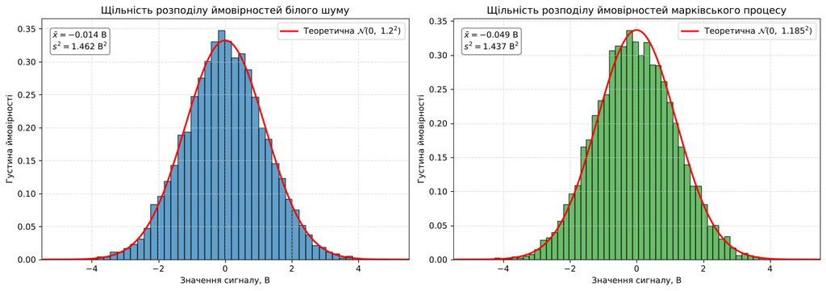

```python
burn = 500
rng = np.random.default_rng(42)                      # фіксація генератора
v_all = rng.normal(0.0, sigma_v, N_samples + burn)
x_all = signal.lfilter([b_param], [1.0, -a_param], v_all)   # x[n] - a x[n-1] = b v[n]
v_white, x_markov = v_all[burn:], x_all[burn:]

def sample_stats(x):
    return float(np.mean(x)), float(np.var(x, ddof=1)), float(np.std(x, ddof=1))

mean_w, var_w, std_w = sample_stats(v_white)
mean_m, var_m, std_m = sample_stats(x_markov)
skew_w, kurt_w = float(stats.skew(v_white)), float(stats.kurtosis(v_white))
skew_m, kurt_m = float(stats.skew(x_markov)), float(stats.kurtosis(x_markov))

print("=" * 96)
print(f"СТАТИСТИЧНІ ХАРАКТЕРИСТИКИ ВИПАДКОВИХ ПРОЦЕСІВ (N = {N_samples})")
print("=" * 96)
print(f"{'':<22}{'мат. очікування, В':>20}{'дисперсія, В²':>16}{'СКВ, В':>10}{'асиметрія':>11}{'ексцес':>9}")
print(f"{'Білий шум v[n]':<22}{mean_w:20.4f}{var_w:16.4f}{std_w:10.4f}{skew_w:11.3f}{kurt_w:9.3f}")
print(f"{'  теорія':<22}{0.0:20.4f}{sigma_v ** 2:16.4f}{sigma_v:10.4f}{0.0:11.3f}{0.0:9.3f}")
print(f"{'Марківський x[n]':<22}{mean_m:20.4f}{var_m:16.4f}{std_m:10.4f}{skew_m:11.3f}{kurt_m:9.3f}")
print(f"{'  теорія':<22}{0.0:20.4f}{var_x_theor:16.4f}{std_x_theor:10.4f}{0.0:11.3f}{0.0:9.3f}")
print("=" * 96)
print(f"Відхилення середнього від 0 у стандартних похибках: білий шум {mean_w / se_white:+.2f}, марківський {mean_m / se_markov:+.2f}")

# --- Ансамблеве моделювання Монте-Карло (R = 1000 реалізацій)
def monte_carlo_moments(R=1000, chunk=100, seed=7):
    rng_mc = np.random.default_rng(seed)
    mw, mm, vw, vm = [], [], [], []
    for _ in range(R // chunk):
        v = rng_mc.normal(0.0, sigma_v, (chunk, N_samples + burn))
        x = signal.lfilter([b_param], [1.0, -a_param], v, axis=1)[:, burn:]
        v = v[:, burn:]
        mw.append(v.mean(axis=1)); mm.append(x.mean(axis=1))
        vw.append(v.var(axis=1, ddof=1)); vm.append(x.var(axis=1, ddof=1))
    return [np.concatenate(z) for z in (mw, mm, vw, vm)]

R_mc = 1000
mw_mc, mm_mc, vw_mc, vm_mc = monte_carlo_moments(R_mc)
print(f"\nАнсамбль із {R_mc} реалізацій по {N_samples} відліків:")
print(f"{'':<18}{'СКВ середнього (MC)':>22}{'теорія SE':>12}{'сер. дисперсія (MC)':>22}{'теорія σ²':>11}")
print(f"{'Білий шум':<18}{mw_mc.std(ddof=1):22.4f}{se_white:12.4f}{vw_mc.mean():22.4f}{sigma_v ** 2:11.4f}")
print(f"{'Марківський':<18}{mm_mc.std(ddof=1):22.4f}{se_markov:12.4f}{vm_mc.mean():22.4f}{var_x_theor:11.4f}")
assert abs(mw_mc.std(ddof=1) / se_white - 1) < 0.1 and abs(mm_mc.std(ddof=1) / se_markov - 1) < 0.1

# --- Гістограми розподілу
x_fine = np.linspace(-5.5, 5.5, 600)
fig, axes = plt.subplots(1, 2, figsize=(14, 5))
for ax, data, sig_t, col, ttl, lab in [
        (axes[0], v_white, sigma_v, '#1f77b4', "Щільність розподілу ймовірностей білого шуму", f'Теоретична $\\mathcal{{N}}(0,\\ {sigma_v}^2)$'),
        (axes[1], x_markov, std_x_theor, '#2ca02c', "Щільність розподілу ймовірностей марківського процесу", f'Теоретична $\\mathcal{{N}}(0,\\ {std_x_theor:.3f}^2)$')]:
    ax.hist(data, bins=50, density=True, color=col, alpha=0.7, edgecolor='black')
    ax.plot(x_fine, stats.norm.pdf(x_fine, 0, sig_t), 'r-', lw=2, label=lab)
    ax.set_title(ttl); ax.set_xlabel("Значення сигналу, В"); ax.set_ylabel("Густина ймовірності")
    mm_, vv_, _ = sample_stats(data)
    ax.text(0.03, 0.95, f"$\\bar x={mm_:+.3f}$ В\n$s^2={vv_:.3f}$ В$^2$", transform=ax.transAxes, va='top', fontsize=10,
            bbox=dict(boxstyle='round', fc='white', ec='gray'))
    ax.set_xlim([-5.5, 5.5]); ax.grid(True); ax.legend(loc='upper right')
plt.tight_layout()
plt.savefig("figures/noise_histograms.png", dpi=200)
plt.show()
```

## 4. Автокореляційний аналіз та інтервал кореляції

АКФ оцінюється зсунутою оцінкою $\hat R[m]=\frac1N\sum(x[n]-\bar x)(x[n+m]-\bar x)$ через швидку кореляцію (`signal.correlate`, метод ШПФ) та нормується на $\hat R[0]$. Результат верифікується прямим обчисленням для перших лагів. Інтервал кореляції — перший лаг, на якому $\hat r[m]\le e^{-1}\approx0.368$ (з лінійною інтерполяцією для порівняння з неперервним теоретичним значенням $6.15$). Додатково параметр моделі оцінюється за рівнянням Юла-Волкера для AR(1): $\hat a=\hat r[1]$.

```
==================================================================================
АВТОКОРЕЛЯЦІЙНИЙ АНАЛІЗ
==================================================================================
Білий шум: r[0] = 1.000; max|r[m]| при m ≥ 1 = 0.0179; 95 % межа ±0.0196; поза межею 0 з 30 лагів (очікується ≈ 1.5)
Марківський: r[1] = 0.8514 (теорія 0.85); r[5] = 0.4546 (теорія 0.4437); r[10] = 0.2270 (теорія 0.1969)
  відхилення від a^|m| на лагах 0..30: СКВ 0.0307, максимум 0.0421
  похибка за Бартлеттом: σ_B[1] = 0.0053, σ_B[10] = 0.0228, σ_B[30] = 0.0249; max|відхилення|/σ_B = 1.69; частка лагів у межах ±2σ_B: 1.00

Інтервал кореляції (рівень 1/e):
  теоретичний (неперервний): 6.15 такту; перший цілий лаг теорії: 7
  практичний (перший лаг із r ≤ 1/e): 7 тактів; з інтерполяцією: 6.51
  за оцінкою â = r[1] = 0.8514: 6.22 такту; b̂ = 0.5239 (задано 0.52)
==================================================================================
```

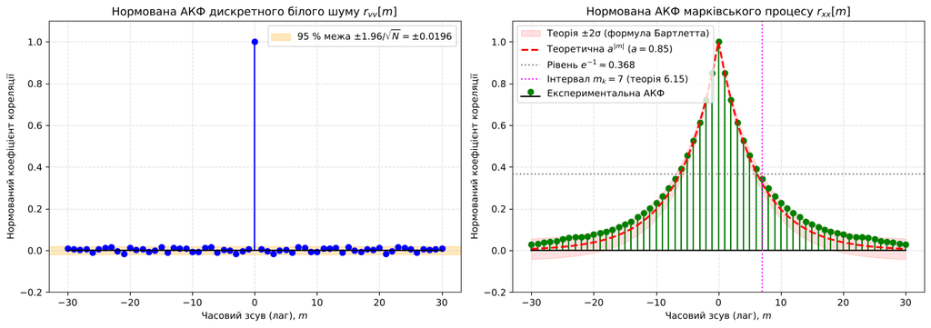

```python
def autocorr_biased(x, max_lag):
    """Зсунена оцінка АКФ R[m] = (1/N) sum (x[n]-mean)(x[n+m]-mean) для лагів -max_lag..max_lag."""
    xc = x - np.mean(x)
    N_ = len(xc)
    r_full = signal.correlate(xc, xc, mode='full', method='fft') / N_
    lags = signal.correlation_lags(N_, N_, mode='full')
    mask = np.abs(lags) <= max_lag
    return lags[mask], r_full[mask]

max_lag = 30
lags_axis, R_white = autocorr_biased(v_white, max_lag)
_, R_markov = autocorr_biased(x_markov, max_lag)
r_white = R_white / R_white[lags_axis == 0][0]
r_markov = R_markov / R_markov[lags_axis == 0][0]
r_theor = a_param ** np.abs(lags_axis)

# Верифікація прямим обчисленням
xc_m = x_markov - x_markov.mean()
for m in range(6):
    direct = np.sum(xc_m[:N_samples - m] * xc_m[m:]) / N_samples
    assert np.isclose(direct, R_markov[lags_axis == m][0])

# Довірчий інтервал та статистика для білого шуму
conf = 1.96 / np.sqrt(N_samples)
nonzero = lags_axis > 0                                     # АКФ симетрична: лічимо додатні лаги 1..30
n_out = int(np.sum(np.abs(r_white[nonzero]) > conf))
# Відхилення експериментальної АКФ марківського процесу від теорії
dev = r_markov - r_theor
pos = lags_axis >= 0
rms_dev = float(np.sqrt(np.mean(dev[pos] ** 2))); max_dev = float(np.max(np.abs(dev[pos])))

# Стандартна похибка оцінки r[m] для AR(1) (формула Бартлетта)
m_pos = np.arange(0, max_lag + 1)
bart_std = np.sqrt(((1 + a_param ** 2) * (1 - a_param ** (2 * m_pos)) / (1 - a_param ** 2) - 2 * m_pos * a_param ** (2 * m_pos)) / N_samples)
bart_axis = bart_std[np.abs(lags_axis)]
z_dev = dev[pos][1:] / bart_std[1:]
frac_2s = float(np.mean(np.abs(z_dev) <= 2))

# Інтервал кореляції
tau = 1.0 / np.e
pos_lags, pos_r = lags_axis[pos], r_markov[pos]
i_tau = int(np.where(pos_r <= tau)[0][0])
m_k_pract = int(pos_lags[i_tau])
m_k_interp = float(pos_lags[i_tau - 1] + (pos_r[i_tau - 1] - tau) / (pos_r[i_tau - 1] - pos_r[i_tau]))
m_k_theor_int = int(np.ceil(m_k_theor))
a_hat = float(r_markov[lags_axis == 1][0])
m_k_from_ahat = -1.0 / np.log(a_hat)
b_hat = np.sqrt(var_m * (1 - a_hat ** 2)) / sigma_v

print("=" * 82)
print("АВТОКОРЕЛЯЦІЙНИЙ АНАЛІЗ")
print("=" * 82)
print(f"Білий шум: r[0] = {r_white[lags_axis == 0][0]:.3f}; max|r[m]| при m ≥ 1 = {np.max(np.abs(r_white[nonzero])):.4f}; "
      f"95 % межа ±{conf:.4f}; поза межею {n_out} з {int(nonzero.sum())} лагів (очікується ≈ {0.05 * nonzero.sum():.1f})")
print(f"Марківський: r[1] = {a_hat:.4f} (теорія {a_param}); r[5] = {r_markov[lags_axis == 5][0]:.4f} (теорія {a_param ** 5:.4f}); r[10] = {r_markov[lags_axis == 10][0]:.4f} (теорія {a_param ** 10:.4f})")
print(f"  відхилення від a^|m| на лагах 0..{max_lag}: СКВ {rms_dev:.4f}, максимум {max_dev:.4f}")
print(f"  похибка за Бартлеттом: σ_B[1] = {bart_std[1]:.4f}, σ_B[10] = {bart_std[10]:.4f}, σ_B[30] = {bart_std[30]:.4f}; "
      f"max|відхилення|/σ_B = {np.max(np.abs(z_dev)):.2f}; частка лагів у межах ±2σ_B: {frac_2s:.2f}")
print(f"\nІнтервал кореляції (рівень 1/e):")
print(f"  теоретичний (неперервний): {m_k_theor:.2f} такту; перший цілий лаг теорії: {m_k_theor_int}")
print(f"  практичний (перший лаг із r ≤ 1/e): {m_k_pract} тактів; з інтерполяцією: {m_k_interp:.2f}")
print(f"  за оцінкою â = r[1] = {a_hat:.4f}: {m_k_from_ahat:.2f} такту; b̂ = {b_hat:.4f} (задано {b_param})")
print("=" * 82)

fig, axes = plt.subplots(1, 2, figsize=(14, 5))
ax = axes[0]
ax.axhspan(-conf, conf, color='orange', alpha=0.25, label=f'95 % межа $\\pm1.96/\\sqrt{{N}}=\\pm{conf:.4f}$')
ax.stem(lags_axis, r_white, linefmt='b-', markerfmt='bo', basefmt='k-')
ax.set_title("Нормована АКФ дискретного білого шуму $r_{vv}[m]$")
ax.set_xlabel("Часовий зсув (лаг), $m$"); ax.set_ylabel("Нормований коефіцієнт кореляції")
ax.set_ylim([-0.2, 1.1]); ax.grid(True); ax.legend(loc='upper right')

ax = axes[1]
ax.fill_between(lags_axis, r_theor - 2 * bart_axis, r_theor + 2 * bart_axis, color='red', alpha=0.12, label='Теорія ±2σ (формула Бартлетта)')
ax.stem(lags_axis, r_markov, linefmt='g-', markerfmt='go', basefmt='k-', label='Експериментальна АКФ')
ax.plot(lags_axis, r_theor, 'r--', lw=2, label=f'Теоретична $a^{{|m|}}$ ($a={a_param}$)')
ax.axhline(tau, color='gray', linestyle=':', label='Рівень $e^{-1}\\approx0.368$')
ax.axvline(m_k_pract, color='magenta', linestyle=':', label=f'Інтервал $m_k={m_k_pract}$ (теорія {m_k_theor:.2f})')
ax.set_title("Нормована АКФ марківського процесу $r_{xx}[m]$")
ax.set_xlabel("Часовий зсув (лаг), $m$"); ax.set_ylabel("Нормований коефіцієнт кореляції")
ax.set_ylim([-0.2, 1.1]); ax.grid(True); ax.legend()
plt.tight_layout()
plt.savefig("figures/acf_comparison.png", dpi=200)
plt.show()
```

## 5. Спектральна щільність потужності: теорема Вінера-Хінчіна

За теоремою Вінера-Хінчіна спектральна щільність потужності є перетворенням Фур'є АКФ: $S(\Omega)=\sum_mR[m]e^{-j\Omega m}$. Для білого шуму $S(\Omega)=\sigma_v^2$ (рівномірна), для AR(1)

$$S_x(\Omega)=\frac{b^2\sigma_v^2}{|1-ae^{-j\Omega}|^2}=\frac{b^2\sigma_v^2}{1-2a\cos\Omega+a^2},$$

```
Нормування: (1/π)∫S_x dΩ = 1.4032 (σ_x² = 1.4032)
S_x(0) = 17.31, S_x(π) = 0.1138; співвідношення 21.8 дБ (за Велчем ≈ 22.6 дБ)
Білий шум: середній рівень за Велчем = 1.452 (теорія σ_v² = 1.440)
```

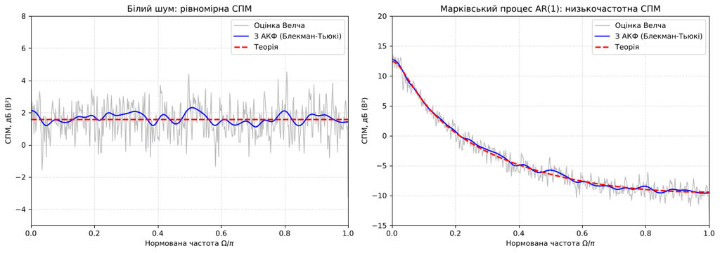

```python
Omega = np.linspace(0, np.pi, 512)
S_white_th = np.full_like(Omega, sigma_v ** 2)
S_markov_th = b_param ** 2 * sigma_v ** 2 / (1 - 2 * a_param * np.cos(Omega) + a_param ** 2)

def psd_welch(x):
    f_, P_ = signal.welch(x, fs=1.0, nperseg=1024, return_onesided=True)     # односторонній -> двосторонній: P/2
    return 2 * np.pi * f_, P_ / 2

def psd_blackman_tukey(x, M=60):
    lg, R_ = autocorr_biased(x, M)
    w_lag = 0.5 * (1 + np.cos(np.pi * lg / M))                               # лагове вікно Ханна
    return np.array([np.sum(R_ * w_lag * np.cos(om * lg)) for om in Omega])

Om_w, S_white_w = psd_welch(v_white)
_, S_markov_w = psd_welch(x_markov)
S_white_bt, S_markov_bt = psd_blackman_tukey(v_white), psd_blackman_tukey(x_markov)

parseval_m = np.trapezoid(S_markov_th, Omega) / np.pi if hasattr(np, 'trapezoid') else np.trapz(S_markov_th, Omega) / np.pi
ratio_th_db = 10 * np.log10(S_markov_th[0] / S_markov_th[-1])
ratio_welch_db = 10 * np.log10(np.mean(S_markov_w[:3]) / np.mean(S_markov_w[-3:]))
print(f"Нормування: (1/π)∫S_x dΩ = {parseval_m:.4f} (σ_x² = {var_x_theor:.4f})")
print(f"S_x(0) = {S_markov_th[0]:.2f}, S_x(π) = {S_markov_th[-1]:.4f}; співвідношення {ratio_th_db:.1f} дБ (за Велчем ≈ {ratio_welch_db:.1f} дБ)")
print(f"Білий шум: середній рівень за Велчем = {np.mean(S_white_w):.3f} (теорія σ_v² = {sigma_v ** 2:.3f})")
assert abs(parseval_m - var_x_theor) < 1e-3

fig, axes = plt.subplots(1, 2, figsize=(14, 5))
db = lambda S: 10 * np.log10(np.maximum(S, 1e-9))
for ax, th, we, bt, ttl in [(axes[0], S_white_th, S_white_w, S_white_bt, "Білий шум: рівномірна СПМ"),
                            (axes[1], S_markov_th, S_markov_w, S_markov_bt, "Марківський процес AR(1): низькочастотна СПМ")]:
    ax.plot(Om_w / np.pi, db(we), color='#bbbbbb', lw=1.0, label='Оцінка Велча')
    ax.plot(Omega / np.pi, db(bt), 'b-', lw=1.6, label='З АКФ (Блекман-Тьюкі)')
    ax.plot(Omega / np.pi, db(th), 'r--', lw=2, label='Теорія')
    ax.set_title(ttl); ax.set_xlabel(r"Нормована частота $\Omega/\pi$"); ax.set_ylabel("СПМ, дБ (В²)")
    ax.set_xlim([0, 1]); ax.grid(True); ax.legend()
axes[0].set_ylim([-5, 8]); axes[1].set_ylim([-15, 20])
plt.tight_layout()
plt.savefig("figures/psd_wiener_khinchin.png", dpi=200)
plt.show()
```

## 6. Кореляційне виявлення коду Баркера в зашумленому каналі

Формується прийнятий сигнал $y[n]=s[n-n_0]+\xi[n]$, $\xi[n]\sim\mathcal N(0,\sigma_{ch}^2)$ ($n_0=220$, $\sigma_{ch}=2$ В), та обчислюється ВКФ з опорним сигналом. Розглядаються лише допустимі затримки $0\le m\le N_{ch}-L_s$ (імпульс повністю вміщується в запис, режим `valid`, 531 кандидат). Затримка оцінюється як позиція максимуму ВКФ. **Про вибір реалізації шуму:** результат однієї реалізації випадковий, тому для ілюстрації береться перша за номером `seed` реалізація з точною оцінкою затримки (це найімовірніший результат, див. Монте-Карло в розділі 7); щоб не створювати хибного враження, додатково виводиться результат для `seed = 99` (реалізація з еталонного прикладу), де шум зсуває пік. Поведінку методу в цілому характеризує розділ 7.

```
АКФ коду Баркера-7 (по 10 відліків на символ): пік 70, макс. бічний рівень 10 (ПБР = 7.0 = 16.9 дБ)
==================================================================================
РЕЗУЛЬТАТИ КОРЕЛЯЦІЙНОГО ВИЯВЛЕННЯ (ілюстративна реалізація, seed = 0)
==================================================================================
ОСШ на вході: -6.02 дБ у межах імпульсу (-15.35 дБ, усереднене по запису)
Істинна затримка:   220 тактів (220 мс)
Оцінена затримка:   220 тактів (220 мс); похибка +0 тактів (символ коду = 10 тактів)
Пік ВКФ: 71.5; значення ВКФ у істинній точці: 71.5 (очікується 70 ± 16.7)
σ_out = 16.73; пік/σ_out = 4.27; найбільший викид поза головним пелюстком 50.8 (3.04σ_out); пік/викид = 1.41
Для порівняння, реалізація seed = 99: n̂0 = 214 (похибка -6), пік 47.3, значення в істинній точці 29.6
==================================================================================
```

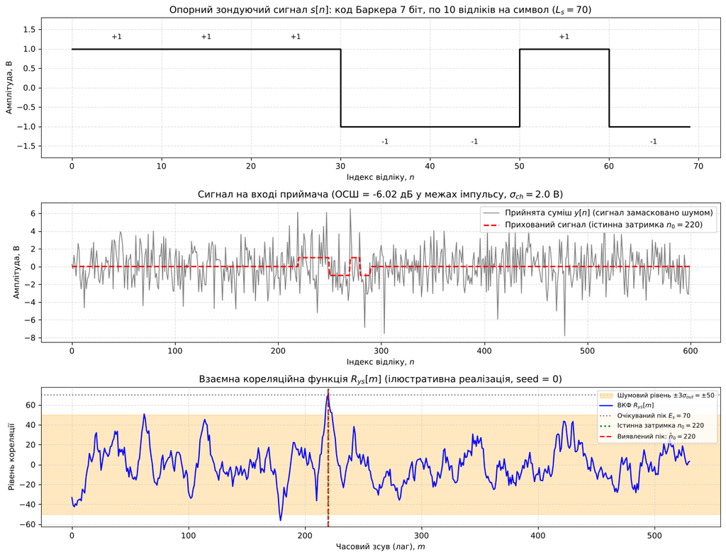

```python
# Автокореляція опорного сигналу: головний пелюсток та бічні рівні
acf_s_full = signal.correlate(s_probe, s_probe, mode='full')
lag_s = signal.correlation_lags(L_s, L_s, mode='full')
side_levels = np.abs(acf_s_full[np.abs(lag_s) >= chip])
psl = float(side_levels.max())
assert np.isclose(acf_s_full[lag_s == 0][0], E_s)
main = np.abs(lag_s) <= chip
assert np.allclose(acf_s_full[main], E_s - len(barker7) * A0 ** 2 * np.abs(lag_s[main]))   # трикутний пік: E_s - 7|m|
print(f"АКФ коду Баркера-7 (по {chip} відліків на символ): пік {E_s:.0f}, макс. бічний рівень {psl:.0f} (ПБР = {E_s / psl:.1f} = {20 * np.log10(E_s / psl):.1f} дБ)")

# Канал
y_clean = np.zeros(N_channel)
y_clean[n0_true:n0_true + L_s] = s_probe
def run_once(seed):
    """Одна реалізація каналу: шум, прийнята суміш, ВКФ (допустимі затримки 0..N_ch - L_s), оцінка затримки."""
    noise = np.random.default_rng(seed).normal(0.0, sigma_ch, N_channel)
    y = y_clean + noise
    r = signal.correlate(y, s_probe, mode='valid', method='direct')
    return noise, y, r, int(np.argmax(r))

# Ілюстративна реалізація: перша за номером seed = 0, 1, 2, ... з оцінкою без похибки (найімовірніший результат
# за Монте-Карло, розділ 7). Для чесного порівняння нижче також наведено реалізацію seed = 99.
seed_demo = next(sd for sd in range(500) if run_once(sd)[3] == n0_true)
channel_noise, y_received, r_ys, n0_est = run_once(seed_demo)
lags_ys = np.arange(len(r_ys))
peak_val = float(r_ys.max())
_, _, r_99, n0_99 = run_once(99)
r_at_true = float(r_ys[n0_true])

# Бічні викиди: максимум |R| поза головним пелюстком +-chip навколо оцінки
mask_side = np.abs(lags_ys - n0_est) > chip
sidelobe_max = float(np.max(r_ys[mask_side]))
pslr_real = peak_val / sidelobe_max

print("=" * 82)
print(f"РЕЗУЛЬТАТИ КОРЕЛЯЦІЙНОГО ВИЯВЛЕННЯ (ілюстративна реалізація, seed = {seed_demo})")
print("=" * 82)
print(f"ОСШ на вході: {snr_in_pulse_db:.2f} дБ у межах імпульсу ({snr_in_record_db:.2f} дБ, усереднене по запису)")
print(f"Істинна затримка:   {n0_true} тактів ({n0_true / fs_loc * 1e3:.0f} мс)")
print(f"Оцінена затримка:   {n0_est} тактів ({n0_est / fs_loc * 1e3:.0f} мс); похибка {n0_est - n0_true:+d} тактів (символ коду = {chip} тактів)")
print(f"Пік ВКФ: {peak_val:.1f}; значення ВКФ у істинній точці: {r_at_true:.1f} (очікується {E_s:.0f} ± {sigma_out:.1f})")
print(f"σ_out = {sigma_out:.2f}; пік/σ_out = {peak_val / sigma_out:.2f}; найбільший викид поза головним пелюстком {sidelobe_max:.1f} ({sidelobe_max / sigma_out:.2f}σ_out); пік/викид = {pslr_real:.2f}")
print(f"Для порівняння, реалізація seed = 99: n̂0 = {n0_99} (похибка {n0_99 - n0_true:+d}), пік {r_99.max():.1f}, значення в істинній точці {r_99[n0_true]:.1f}")
print("=" * 82)

fig, axes = plt.subplots(3, 1, figsize=(13, 10))
ax = axes[0]
ax.plot(np.arange(L_s), s_probe, 'k-', lw=1.8, drawstyle='steps-post')
for k, c in enumerate(barker7):
    ax.text(k * chip + chip / 2, 1.25 * np.sign(c) if c > 0 else -1.45, f"{int(c):+d}", ha='center', fontsize=9)
ax.set_title(f"Опорний зондуючий сигнал $s[n]$: код Баркера 7 біт, по {chip} відліків на символ ($L_s={L_s}$)")
ax.set_xlabel("Індекс відліку, $n$"); ax.set_ylabel("Амплітуда, В"); ax.set_ylim([-1.8, 1.8]); ax.grid(True)

ax = axes[1]
ax.plot(np.arange(N_channel), y_received, color='#7f7f7f', lw=1.0, label='Прийнята суміш $y[n]$ (сигнал замасковано шумом)')
ax.plot(np.arange(N_channel), y_clean, 'r--', lw=1.8, label=f'Прихований сигнал (істинна затримка $n_0={n0_true}$)')
ax.set_title(f"Сигнал на вході приймача (ОСШ = {snr_in_pulse_db:.2f} дБ у межах імпульсу, $\\sigma_{{ch}}={sigma_ch}$ В)")
ax.set_xlabel("Індекс відліку, $n$"); ax.set_ylabel("Амплітуда, В"); ax.grid(True); ax.legend(loc='upper right')

ax = axes[2]
ax.axhspan(-3 * sigma_out, 3 * sigma_out, color='orange', alpha=0.25, label=f'Шумовий рівень $\\pm3\\sigma_{{out}}=\\pm{3 * sigma_out:.0f}$')
ax.plot(lags_ys, r_ys, 'b-', lw=1.5, label='ВКФ $R_{ys}[m]$')
ax.axhline(E_s, color='gray', ls=':', label=f'Очікуваний пік $E_s={E_s:.0f}$')
ax.axvline(n0_true, color='g', ls=':', lw=2, label=f'Істинна затримка $n_0={n0_true}$')
ax.axvline(n0_est, color='r', ls='--', lw=1.6, label=f'Виявлений пік: $\\hat n_0={n0_est}$')
ax.set_title(f"Взаємна кореляційна функція $R_{{ys}}[m]$ (ілюстративна реалізація, seed = {seed_demo})")
ax.set_xlabel("Часовий зсув (лаг), $m$"); ax.set_ylabel("Рівень кореляції"); ax.grid(True); ax.legend(loc='upper right', fontsize=8)
plt.tight_layout()
plt.savefig("figures/radar_detection_ccf.png", dpi=200)
plt.show()
```

## 7. Статистика виявлення: метод Монте-Карло

Одна реалізація не характеризує метод (її результат залежить від випадкового шуму), тому виявлення повторюється для $R=2000$ незалежних реалізацій шуму:

- розподіл похибки оцінки затримки $\hat n_0-n_0$, ймовірності влучання (точно, у межах $\pm5$ відліків — півсимвола, та $\pm10$ — одного символу), СКО похибки без грубих промахів;
- виявлення за порогом: гіпотеза $H_0$ (лише шум) та $H_1$ (сигнал + шум); поріг для максимуму ВКФ вибирається за ймовірності хибної тривоги $P_{fa}=1\ \%$ (99-й перцентиль максимумів при $H_0$), далі оцінюється ймовірність виявлення $P_D$;
- залежність імовірності влучання від ОСШ (розвертка за $\sigma_{ch}$, $R=1000$ реалізацій на точку).

```
================================================================================
МОНТЕ-КАРЛО ВИЯВЛЕННЯ (σ_ch = 2.0 В, ОСШ = -6.02 дБ, R = 2000)
================================================================================
Похибка оцінки затримки: середня +0.01, СКО (без грубих промахів) 1.32 такту; межі: -220...305
Імовірність: точно (0) = 0.565; |ε| ≤ 5 = 0.921; |ε| ≤ 10 = 0.926; грубий промах (|ε| > 10) = 0.074
Максимум ВКФ: при H1 середній 72.7 (теорія 70 + зсув від вибору максимуму), при H0 середній 47.2, СКВ 7.0
Поріг при P_fa = 1 %: 66.9 (4.00σ_out) -> імовірність виявлення P_D = 0.625

 σ_ch, В   ОСШ, дБ   P(ε=0)  P(|ε|≤5)  P(|ε|≤10)
     1.0      0.00    0.946     1.000      1.000
     1.5     -3.52    0.753     0.997      0.997
     2.0     -6.02    0.555     0.929      0.933
     3.0     -9.54    0.286     0.604      0.626
     4.0    -12.04    0.139     0.402      0.426
     6.0    -15.56    0.037     0.171      0.191
```

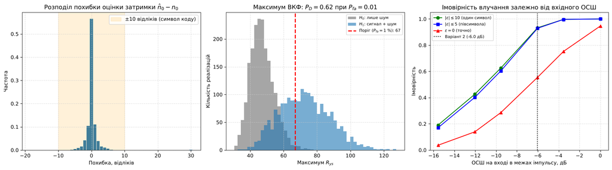

```python
def detection_trials(sigma, R, seed, with_signal=True):
    rng_t = np.random.default_rng(seed)
    errs = np.empty(R, dtype=int); peaks = np.empty(R)
    for i in range(R):
        y = (y_clean if with_signal else 0.0) + rng_t.normal(0.0, sigma, N_channel)
        r = signal.correlate(y, s_probe, mode='valid', method='direct')
        k = int(np.argmax(r)); errs[i] = k - n0_true; peaks[i] = r[k]
    return errs, peaks

R_det = 2000
errs_h1, peaks_h1 = detection_trials(sigma_ch, R_det, seed=2026, with_signal=True)
_, peaks_h0 = detection_trials(sigma_ch, R_det, seed=2027, with_signal=False)

p_exact = float(np.mean(errs_h1 == 0))
p_half = float(np.mean(np.abs(errs_h1) <= chip // 2))
p_chip = float(np.mean(np.abs(errs_h1) <= chip))
gross = np.abs(errs_h1) > chip
rms_err = float(np.sqrt(np.mean(errs_h1[~gross] ** 2)))
thr = float(np.percentile(peaks_h0, 99))
P_D = float(np.mean(peaks_h1 > thr))

print("=" * 80)
print(f"МОНТЕ-КАРЛО ВИЯВЛЕННЯ (σ_ch = {sigma_ch} В, ОСШ = {snr_in_pulse_db:.2f} дБ, R = {R_det})")
print("=" * 80)
print(f"Похибка оцінки затримки: середня {errs_h1[~gross].mean():+.2f}, СКО (без грубих промахів) {rms_err:.2f} такту; "
      f"межі: {errs_h1.min()}...{errs_h1.max()}")
print(f"Імовірність: точно (0) = {p_exact:.3f}; |ε| ≤ {chip // 2} = {p_half:.3f}; |ε| ≤ {chip} = {p_chip:.3f}; грубий промах (|ε| > {chip}) = {1 - p_chip:.3f}")
print(f"Максимум ВКФ: при H1 середній {peaks_h1.mean():.1f} (теорія {E_s:.0f} + зсув від вибору максимуму), при H0 середній {peaks_h0.mean():.1f}, СКВ {peaks_h0.std():.1f}")
print(f"Поріг при P_fa = 1 %: {thr:.1f} ({thr / sigma_out:.2f}σ_out) -> імовірність виявлення P_D = {P_D:.3f}")

# Розвертка за рівнем шуму
sigmas = [1.0, 1.5, 2.0, 3.0, 4.0, 6.0]
snr_sweep = [10 * np.log10(A0 ** 2 / s ** 2) for s in sigmas]
p5_sweep, p10_sweep, pex_sweep = [], [], []
for s_ in sigmas:
    e_, _ = detection_trials(s_, 1000, seed=int(100 * s_))
    p5_sweep.append(np.mean(np.abs(e_) <= chip // 2)); p10_sweep.append(np.mean(np.abs(e_) <= chip)); pex_sweep.append(np.mean(e_ == 0))
print(f"\n{'σ_ch, В':>8}{'ОСШ, дБ':>10}{'P(ε=0)':>9}{'P(|ε|≤5)':>10}{'P(|ε|≤10)':>11}")
for s_, q, p0, p5, p10 in zip(sigmas, snr_sweep, pex_sweep, p5_sweep, p10_sweep):
    print(f"{s_:8.1f}{q:10.2f}{p0:9.3f}{p5:10.3f}{p10:11.3f}")

fig, axes = plt.subplots(1, 3, figsize=(17, 4.8))
ax = axes[0]
vals, cnts = np.unique(errs_h1[np.abs(errs_h1) <= 30], return_counts=True)
ax.bar(vals, cnts / R_det, color='#1f77b4', width=0.9)
ax.axvspan(-chip, chip, color='orange', alpha=0.15, label=f'$\\pm${chip} відліків (символ коду)')
ax.set_title("Розподіл похибки оцінки затримки $\\hat n_0 - n_0$")
ax.set_xlabel("Похибка, відліків"); ax.set_ylabel("Частота"); ax.grid(True); ax.legend()

ax = axes[1]
bins = np.linspace(min(peaks_h0.min(), peaks_h1.min()), peaks_h1.max(), 50)
ax.hist(peaks_h0, bins=bins, color='gray', alpha=0.7, label='$H_0$: лише шум')
ax.hist(peaks_h1, bins=bins, color='#1f77b4', alpha=0.6, label='$H_1$: сигнал + шум')
ax.axvline(thr, color='r', ls='--', lw=2, label=f'Поріг ($P_{{fa}}=1\\ \\%$): {thr:.0f}')
ax.set_title(f"Максимум ВКФ: $P_D={P_D:.2f}$ при $P_{{fa}}=0.01$")
ax.set_xlabel("Максимум $R_{ys}$"); ax.set_ylabel("Кількість реалізацій"); ax.grid(True); ax.legend(fontsize=8)

ax = axes[2]
ax.plot(snr_sweep, p10_sweep, 'go-', label='$|\\varepsilon|\\leq10$ (один символ)')
ax.plot(snr_sweep, p5_sweep, 'bs-', label='$|\\varepsilon|\\leq5$ (півсимвола)')
ax.plot(snr_sweep, pex_sweep, 'r^-', label='$\\varepsilon=0$ (точно)')
ax.axvline(snr_in_pulse_db, color='k', ls=':', label=f'Варіант 2 ({snr_in_pulse_db:.1f} дБ)')
ax.set_title("Імовірність влучання залежно від вхідного ОСШ")
ax.set_xlabel("ОСШ на вході в межах імпульсу, дБ"); ax.set_ylabel("Імовірність"); ax.set_ylim([0, 1.05]); ax.grid(True); ax.legend(fontsize=8)
plt.tight_layout()
plt.savefig("figures/detection_monte_carlo.png", dpi=200)
plt.show()
```

## 8. Експорт результатів

```python
np.savetxt("data/noise_samples.csv", np.column_stack([np.arange(N_samples), v_white, x_markov]),
           delimiter=",", header="n,v_white,x_markov", comments="")
np.savetxt("data/acf.csv", np.column_stack([lags_axis, r_white, r_markov, r_theor]),
           delimiter=",", header="lag,r_white,r_markov,r_markov_theory", comments="")
np.savetxt("data/radar_signals.csv",
           np.column_stack([np.arange(N_channel), y_received, y_clean, np.r_[r_ys, np.full(N_channel - len(r_ys), np.nan)]]),
           delimiter=",", header="n,y_received,y_clean_delayed,ccf_valid_lags", comments="")

results = dict(
    variant=2,
    params=dict(a=a_param, b=b_param, sigma_v=sigma_v, N=N_samples, probe="Barker-7", L_s=L_s, chip=chip, n0=n0_true,
                sigma_ch=sigma_ch, fs=fs_loc, A0=A0, N_channel=N_channel),
    theory=dict(var_x=var_x_theor, std_x=std_x_theor, m_k=m_k_theor, se_mean_white=se_white, se_mean_markov=se_markov, N_eff=N_eff,
                E_s=E_s, sigma_out=sigma_out, snr_in_pulse_db=snr_in_pulse_db, snr_in_record_db=float(snr_in_record_db),
                snr_out_db=snr_out_db, gain_db=gain_db, psl=psl),
    sample=dict(white=dict(mean=mean_w, var=var_w, std=std_w, skew=skew_w, kurt=kurt_w),
                markov=dict(mean=mean_m, var=var_m, std=std_m, skew=skew_m, kurt=kurt_m)),
    monte_carlo_moments=dict(R=R_mc, std_mean_white=float(mw_mc.std(ddof=1)), std_mean_markov=float(mm_mc.std(ddof=1)),
                             mean_var_white=float(vw_mc.mean()), mean_var_markov=float(vm_mc.mean())),
    acf=dict(r1=a_hat, rms_dev=rms_dev, max_dev=max_dev, bartlett_sigma_30=float(bart_std[30]), max_dev_over_sigma_B=float(np.max(np.abs(z_dev))), frac_within_2sigma_B=frac_2s, conf95=conf, white_out_of_band=n_out, m_k_practical=m_k_pract,
             m_k_interpolated=m_k_interp, m_k_theory=m_k_theor, m_k_from_a_hat=float(m_k_from_ahat), b_hat=float(b_hat)),
    detection_single=dict(seed=seed_demo, n0_estimated=n0_est, seed99_n0_estimated=n0_99, seed99_peak=float(r_99.max()), seed99_value_at_true=float(r_99[n0_true]), error=n0_est - n0_true, peak=peak_val, value_at_true=r_at_true,
                          sidelobe_max=sidelobe_max, pslr=float(pslr_real)),
    detection_mc=dict(R=R_det, p_exact=p_exact, p_half_chip=p_half, p_chip=p_chip, rms_error_no_gross=rms_err,
                      threshold_pfa1=thr, P_D=P_D, sweep=dict(sigma_ch=sigmas, snr_db=snr_sweep, p_exact=pex_sweep,
                                                              p_half_chip=p5_sweep, p_chip=p10_sweep)),
)
with open("data/results.json", "w", encoding="utf-8") as f:
    json.dump(results, f, ensure_ascii=False, indent=1, default=float)
print("Готово: figures/, data/")
```

```
Готово: figures/, data/
```

## Висновки

1. **Числові характеристики.** Для білого шуму $v[n]\sim\mathcal N(0,1.2^2)$ отримано $\bar v=-0.014$ В, $s^2=1.462$ В² (теорія $0$ та $1.44$ В²); для марківського процесу з $a=0.85$, $b=0.52$ — $\bar x=-0.049$ В, $s^2=1.437$ В² при теоретичній дисперсії $\sigma_x^2=b^2\sigma_v^2/(1-a^2)=1.403$ В² (СКВ $1.199$ проти $1.185$ В). Гістограми добре збігаються з гаусовими кривими (асиметрія $\approx0$, ексцес $\approx0$). Дисперсія процесу при $\sigma_v=1.2$ не дорівнює одиниці, на відміну від еталонного прикладу.
2. **Ергодичність та точність оцінок.** Ансамбль із 1000 реалізацій по 10000 відліків показав: розкид вибіркового середнього дорівнює $0.0119$ В (білий шум, теорія $0.0120$ В) і $0.0412$ В (марківський, теорія $0.0416$ В), середні вибіркові дисперсії збігаються з теорією ($1.440$ та $1.402$ В²). Корельований процес має в ≈3.5 раза більшу похибку середнього, бо $N_{eff}\approx N(1-a)/(1+a)\approx811$ незалежних відліків замість 10000; тому відхилення середнього $-0.049$ В (1.2 стандартної похибки) у межах норми. Отже, для ергодичного процесу часове усереднення по одній реалізації збігається з ансамблевим, але для сильно корельованих процесів потрібна довша вибірка.
3. **АКФ та інтервал кореляції.** АКФ білого шуму дельта-подібна: $\max|\hat r[m]|=0.018$ при $m\ge1$ лежить усередині 95 % межі $\pm0.0196$ (жоден з 30 лагів її не перевищив), тобто $m_k=0$. АКФ марківського процесу експоненційно спадає: $\hat r[1]=0.851$, $\hat r[5]=0.455$, $\hat r[10]=0.227$ (теорія $0.85$; $0.444$; $0.197$); відхилення від $a^{|m|}$ (СКВ $0.031$, максимум $0.042$) не перевищує $1.7\sigma_B$ за формулою Бартлетта ($\sigma_B\approx0.025$ при великих лагах), тобто пояснюється статистичною похибкою оцінки. Інтервал кореляції за рівнем $e^{-1}$: теорія $6.15$ такту (перший цілий лаг $7$), практично $7$ тактів ($6.51$ з інтерполяцією); за оцінкою Юла-Волкера $\hat a=\hat r[1]=0.851$ — $6.22$ такту, $\hat b=0.524$ (задано $0.52$). Чим ближче $a$ до 1, тим довший інтервал кореляції та сильніший статистичний зв'язок сусідніх відліків.
4. **Спектральна щільність (Вінер-Хінчін).** СПМ марківського процесу $S_x(\Omega)=b^2\sigma_v^2/(1-2a\cos\Omega+a^2)$ має низькочастотну форму: $S(0)=17.31$, $S(\pi)=0.114$ (різниця $21.8$ дБ; за Велчем $\approx22.6$ дБ), а нормування $\frac1\pi\int S\,d\Omega=1.403$ В² збігається з дисперсією. Оцінка з АКФ (Блекман-Тьюкі) та оцінка Велча збігаються з теорією; СПМ білого шуму рівномірна ($1.452$ за Велчем при теоретичних $1.44$ В²). Звуження АКФ відповідає розширенню СПМ і навпаки.
5. **Кореляційне виявлення (одна реалізація).** Код Баркера-7 (по 10 відліків на символ) має автокореляційний пік $E_s=70$ при максимальному бічному рівні 10 (ПБР $7$, $16.9$ дБ). У каналі з $\sigma_{ch}=2$ В вхідне ОСШ у межах імпульсу становить $-6.02$ дБ ($-15.35$ дБ в середньому по запису), амплітуда сигналу $1$ В менша за СКВ шуму, а $|\xi|>A_0$ у $61.7$ % відліків, тож сигнал на осцилограмі не видно. Кореляційна обробка дає пікове ОСШ $12.4$ дБ (виграш $10\lg L_s=18.45$ дБ). В ілюстративній реалізації (перша за номером `seed` з точною оцінкою, `seed = 0`) пік ВКФ $71.5$ ($4.27\sigma_{out}$, очікується $70$) припадає на $\hat n_0=220$, найбільший викид шуму поза головним пелюстком $50.8$. Для порівняння, у реалізації `seed = 99` шум зсунув пік на $-6$ відліків ($\hat n_0=214$, пік $47.3$, значення в істинній точці $29.6$): результат однієї реалізації випадковий.
6. **Статистика виявлення (Монте-Карло, 2000 реалізацій).** Затримка оцінюється точно в $56.5$ % випадків, у межах $\pm5$ відліків — у $92.1$ %, у межах одного символу ($\pm10$) — у $92.6$ %, грубі промахи складають $7.4$ %; СКО похибки без грубих промахів $1.32$ такту. Неточність на кілька відліків закономірна: трикутний пік $R_{ss}[m]=E_s-7|m|$ спадає лише на 7 за відлік, тоді як $\sigma_{out}=16.7$. Для порогу з імовірністю хибної тривоги $P_{fa}=1$ % (поріг $66.9=4.0\sigma_{out}$) ймовірність виявлення $P_D=0.62$. Залежність від ОСШ: влучання в межах $\pm5$ відліків — $100$ % при $0$ дБ, $99.7$ % при $-3.5$ дБ, $92.9$ % при $-6.0$ дБ, $60.4$ % при $-9.5$ дБ та $17.1$ % при $-15.6$ дБ. Отже, кореляційний прийом надійно виявляє та локалізує сигнал, амплітуда якого нижча за рівень шуму, але для виявлення з малою хибною тривогою при ОСШ нижче $-6$ дБ на одному імпульсі потрібен довший код (Баркера-13) або накопичення кількох імпульсів.

## Контрольні питання:

### 1. У чому полягає фізична та статистична відмінність між поняттями стаціонарного у широкому сенсі та ергодичного випадкового процесу?

- **Стаціонарний у широкому сенсі випадковий процес (WSS — *Wide-Sense Stationary*):**
- **Статистичний зміст:** Математичне сподівання процесу (середнє за ансамблем реалізацій) є сталим у часі ($m_x[n] = \mathbb{E}\{x[n]\} = \text{const}$), а його автокореляційна функція (АКФ) залежить лише від часового зсуву $m = n_1 - n_2$, а не від абсолютних моментів часу:

$$R_{xx}[n_1, n_2] = \mathbb{E}\{x[n_1]x^*[n_2]\} = R_{xx}[m]$$

- **Фізичний зміст:** Статистичні властивості сукупності (ансамблю) всіх можливих реалізацій процесу не змінюються в часі — джерело сигналу перебуває в усталеному режимі, а його середня потужність та частотний склад стабільні. Проте окремі реалізації в ансамблі можуть мати різні індивідуальні параметри (наприклад, різну постійну складову чи початкову фазу).
- **Ергодичний випадковий процес:**
- **Статистичний зміст:** Це стаціонарний процес, для якого усереднення за часом по **одній нескінченно довгій реалізації** з імовірністю 1 збігається з усередненням за ансамблем усіх реалізацій:

$$\lim_{N \to \infty} \frac{1}{2N+1} \sum_{n=-N}^{N} x[n] = \mathbb{E}\{x[n]\}, \qquad \lim_{N \to \infty} \frac{1}{2N+1} \sum_{n=-N}^{N} x[n]x^*[n-m] = R_{xx}[m]$$

- **Фізичний зміст:** Кожна окрема реалізація процесу з плином часу проходить через усі можливі статистичні стани, характерні для всього ансамблю. На практиці це дає змогу оцінювати статистичні параметри сигналу (середнє, дисперсію, АКФ, спектр) за одним експериментальним записом достатньої тривалості замість проведення великої серії однакових дослідів.
- **Головна відмінність:** Кожен ергодичний процес є стаціонарним, але не кожен стаціонарний процес є ергодичним (наприклад, процес $x[n] = A$, де $A$ — випадкова величина, постійна в межах кожної окремої реалізації, є стаціонарним, проте не ергодичним, оскільки часове середнє однієї реалізації дорівнює конкретному значенню $A_i$, а не середньому по ансамблю $\mathbb{E}\{A\}$).

### 2. Які властивості має автокореляційна функція (АКФ) стаціонарного дискретного сигналу в точці нульового часового зсуву ($m = 0$) та при віддаленні від початку координат ($m \to \infty$)?

- **У точці нульового часового зсуву ($m = 0$):**
- **Глобальний максимум:** АКФ досягає свого найбільшого за модулем значення саме при нульовому зсуві ($\vert{}R_{xx}[m]\vert{} \le R_{xx}[0]$ для всіх $m \neq 0$), оскільки при $m = 0$ сигнал повністю збігається сам із собою.
- **Фізичний та статистичний зміст:** Значення $R_{xx}[0] = \mathbb{E}\{\vert{}x[n]\vert{}^2\}$ дорівнює **середній повній потужності** стаціонарного дискретного сигналу. Якщо сигнал центрований ($m_x = 0$), то $R_{xx}[0] = \sigma_x^2$ — дорівнює його **дисперсії** (потужності змінної складової).
- **При віддаленні від початку координат ($m \to \infty$):**
- **Згасання кореляції (для випадкових процесів без періодичних складових):** Із зростанням часового зсуву статистичний зв'язок між відліками $x[n]$ та $x[n-m]$ слабшає і зникає, тому АКФ асимптотично прямує до квадрата математичного сподівання процесу:

$$\lim_{m \to \infty} R_{xx}[m] = m_x^2 = \left(\mathbb{E}\{x[n]\}\right)^2$$

Для центрованого процесу ($m_x = 0$) автокореляційна функція прямує до нуля: $\lim_{m \to \infty} R_{xx}[m] = 0$.

- **Наявність прихованої періодичності:** Якщо сигнал містить детерміновану періодичну компоненту, АКФ при $m \to \infty$ не затухає до константи, а зберігає незатухаючі коливання з тим самим періодом.

### 3. Чому автокореляційна функція дискретного білого шуму має вигляд дискретного імпульсу Кронекера $\sigma^2\delta[m]$, і яке значення має його інтервал кореляції?

- **Причина вигляду $\sigma^2\delta[m]$:**
- Дискретний білий шум $w[n]$ є стаціонарним центрованим ($\mathbb{E}\{w[n]\} = 0$) випадковим процесом, відліки якого в різні моменти часу ($m \neq 0$) є **взаємно некорельованими**:

$$R_{ww}[m] = \mathbb{E}\{w[n]w[n-m]\} = \mathbb{E}\{w[n]\}\mathbb{E}\{w[n-m]\} = 0 \quad \text{при } m \neq 0$$

- При нульовому зсуві ($m = 0$) відлік перемножується сам на себе, що дає дисперсію (середню потужність) шуму:

$$R_{ww}[0] = \mathbb{E}\{w^2[n]\} = \sigma^2$$

- Оскільки дельта-функція Кронекера дорівнює $\delta[0] = 1$ при $m = 0$ та $\delta[m] = 0$ при $m \neq 0$, обидві умови записуються єдиною формулою:

$$R_{ww}[m] = \sigma^2\delta[m]$$

*(Перетворення Фур'є від $\sigma^2\delta[m]$ дає рівномірну спектральну щільність потужності $S_{ww}(e^{j\omega}) = \sigma^2 = \text{const}$ на всіх частотах, звідки й походить термін «білий» шум).*

- **Значення інтервалу кореляції:**
- Інтервал кореляції дискретного білого шуму дорівнює **нулю** ($\tau_k = 0$ відліків). Це означає повну відсутність статистичної «пам'яті» процесу: значення поточного відліку $w[n]$ ніяк не пов'язане з попередніми чи наступними відліками $w[n \pm 1]$.

### 4. Яким чином коефіцієнт зворотного зв'язку $a$ в моделі марківського авторегресійного процесу першого порядку $\text{AR}(1)$ впливає на ширину інтервалу кореляції $\tau_k$ та форму спектральної щільності потужності?

Модель $\text{AR}(1)$ описується різницевим рівнянням $x[n] = a x[n-1] + w[n]$ (умова стійкості та стаціонарності: $\vert{}a\vert{} < 1$, $w[n]$ — білий шум із дисперсією $\sigma_w^2$). Її нормована АКФ має вигляд $\rho_{xx}[m] = a^{\vert{}m\vert{}}$, а спектральна щільність потужності (PSD):

$$S_{xx}(e^{j\omega}) = \frac{\sigma_w^2}{\vert{}1 - a e^{-j\omega}\vert{}^2} = \frac{\sigma_w^2}{1 - 2a\cos\omega + a^2}$$

- **Вплив на ширину інтервалу кореляції $\tau_k$:**
- Інтервал кореляції визначається модулем коефіцієнта $\vert{}a\vert{}$ (наприклад, за спадом АКФ у $e$ разів: $\tau_k = -\frac{1}{\ln\vert{}a\vert{}}$, або за сумою модулів нормованої АКФ: $\tau_k = \frac{1 + \vert{}a\vert{}}{1 - \vert{}a\vert{}}$).
- **При $\vert{}a\vert{} \to 0$:** вплив попереднього відліку слабшає, АКФ швидко згасає, а **інтервал кореляції $\tau_k$ звужується** (прямує до $0$, процес наближається до білого шуму).
- **При $\vert{}a\vert{} \to 1$:** зростає інерційність системи, сусідні відліки сильно скорельовані між собою, АКФ затухає повільно, тому **інтервал кореляції $\tau_k$ різко розширюється** ($\tau_k \to \infty$).
- **Вплив на форму спектральної щільності потужності (PSD):**
- **При $a = 0$:** спектр плоский (рівномірний на всіх частотах), як у білого шуму: $S_{xx}(e^{j\omega}) = \sigma_w^2$.
- **При $0 < a < 1$ (додатний зворотний зв'язок):** процес діє як фільтр нижніх частот (ФНЧ) — спектр має **максимум на низьких частотах** ($\omega = 0$, де $S(0) = \frac{\sigma_w^2}{(1-a)^2}$) і спадає зі зростанням частоти. Чим ближче $a \to 1$, тим вищим і вужчим є низькочастотний підйом («червоний» шум).
- **При $-1 < a < 0$ (від'ємний зворотний зв'язок):** сусідні відліки постійно змінюють знак, процес діє як фільтр верхніх частот (ФВЧ) — спектр має **максимум на високих частотах** поблизу частоти Найквіста ($\omega = \pm\pi$, де $S(\pi) = \frac{\sigma_w^2}{(1+a)^2}$) і мінімум на нульовій частоті («синій» шум).

### 5. У чому полягає сутність теореми Вінера-Хінчіна, і як пов'язані між собою автокореляційна функція сигналу та його спектральна щільність потужності (Power Spectral Density – PSD)?

- **Сутність теореми Вінера-Хінчіна:**
- Реалізації нескінченного стаціонарного випадкового процесу мають нескінченну енергію і не є абсолютно сумовними, тому до них неможливо напряму застосувати класичне перетворення Фур'є. Теорема Вінера-Хінчіна встановлює, що розподіл середньої потужності стаціонарного у широкому сенсі випадкового процесу за частотами (PSD) однозначно визначається через перетворення Фур'є його автокореляційної функції (яка для процесів без періодичних компонент згасає при $m \to \infty$ і задовольняє умову існування перетворення Фур'є).
- **Математичний зв'язок між АКФ та PSD:**
- Для дискретного стаціонарного сигналу автокореляційна функція $R_{xx}[m]$ та спектральна щільність потужності $S_{xx}(e^{j\omega})$ утворюють **пару дискретно-часових перетворень Фур'є (DTFT)**:
1. **Пряме перетворення** (розрахунок PSD за відомою АКФ):

$$S_{xx}(e^{j\omega}) = \sum_{m=-\infty}^{\infty} R_{xx}[m] e^{-j\omega m}$$

2. **Обернене перетворення** (відновлення АКФ за відомою PSD):

$$R_{xx}[m] = \frac{1}{2\pi} \int_{-\pi}^{\pi} S_{xx}(e^{j\omega}) e^{j\omega m} \, d\omega$$

- Зокрема, при $m = 0$ повна середня потужність процесу дорівнює інтегралу від PSD по всій смузі частот: $R_{xx}[0] = \frac{1}{2\pi}\int_{-\pi}^{\pi} S_{xx}(e^{j\omega})\,d\omega$. Оскільки АКФ дійсного стаціонарного процесу є парною функцією ($R_{xx}[-m] = R_{xx}[m]$), його PSD завжди є **дійсною, невід'ємною ($S_{xx}(e^{j\omega}) \ge 0$) та парною** функцією частоти.

### 6. Чому функція взаємної кореляції (ВКФ) досягає свого екстремуму в момент збігу часових зсувів двох сигналів, і яким чином це дозволяє виявляти сигнали при співвідношенні сигнал/шум $\text{SNR} \ll 0\text{ дБ}$?

- **Чому ВКФ досягає екстремуму при збігу зсувів:**
- Нехай прийнята суміш має вигляд $y[n] = s[n - m_0] + w[n]$, де $s[n - m_0]$ — корисний сигнал із затримкою $m_0$, $w[n]$ — адитивний шум, а $s[n]$ — відома опорна копія сигналу. Взаємна кореляційна функція дорівнює:

$$R_{ys}[m] = \sum_{n} y[n] s^*[n - m] = R_{ss}[m - m_0] + R_{ws}[m]$$

- За нерівністю Коші — Буняковського для сигнальної складової виконується:

$$\left\vert{} \sum_{n} s[n - m_0] s^*[n - m] \right\vert{}^2 \le \sum_{n} \vert{}s[n - m_0]\vert{}^2 \cdot \sum_{n} \vert{}s[n - m]\vert{}^2 = E_s^2$$

Знак рівності (глобальний екстремум, що дорівнює повній енергії сигналу $E_s$) досягається **виключно при $m = m_0$**, коли всі відліки опорного та прийнятого сигналів збігаються за часом і фазою та підсумовуються **когерентно** (однознаково). При $m \neq m_0$ відліки мають різні знаки або фази та взаємно компенсуються.

- **Механізм виявлення сигналів при $\text{SNR} \ll 0\text{ дБ}$:**
- **Когерентне накопичення сигналу:** При обчисленні кореляції на інтервалі з $N$ відліків корисний сигнал підсумовується *когерентно* за амплітудою, тому висота кореляційного піку зростає пропорційно кількості відліків $N$ (а потужність піку — як $N^2$).
- **Некогерентне усереднення шуму:** Оскільки шум $w[n]$ не скорельований з еталоном $s[n]$ ($R_{ws}[m] \approx 0$), його відліки додаються *некогерентно* (із випадковими знаками), тому дисперсія шуму на виході корелятора зростає лише пропорційно $N$ (а середньоквадратичне відхилення — як $\sqrt{N}$).
- **Виграш в обробці (Processing Gain):** Співвідношення сигнал/шум на виході корелятора збільшується в $N$ разів (на $10\lg N$ дБ). Завдяки цьому енергія сигналу, «розмазана» в часі нижче рівня шуму, концентрується в одному вузькому кореляційному піку, який чітко перевищує поріг виявлення навіть при $\text{SNR} \ll 0\text{ дБ}$.

### 7. Чим відрізняється поведінка кореляційного піку для простого гармонійного радіоімпульсу та для складного фазоманіпульованого сигналу (наприклад, коду Баркера або ЛЧМ-імпульсу)?

Кореляційні властивості визначаються базою сигналу $B = \Delta f \cdot T$ (добутком ширини спектра $\Delta f$ на тривалість імпульсу $T$).

- **Простий гармонійний радіоімпульс ($B \approx 1$):**
- **Широкий головний пелюсток (низька роздільна здатність):** обвідна автокореляційної функції має трикутну форму із загальною шириною основи $2T$ (ширина за рівнем $0{,}5$ дорівнює $T$), заповнену високочастотними коливаннями несучої.
- **Жорсткий зв'язок між енергією та точністю:** для підвищення енергії імпульсу (дальності дії) потрібно збільшувати його тривалість $T$, але це пропорційно розширює кореляційний пік і погіршує точність вимірювання затримки та здатність розрізняти два близькі за часом сигнали.
- **Відсутність бічних пелюстків:** поза межами інтервалу $[-T, T]$ автокореляційна функція дорівнює нулю.
- **Складний сигнал із великою базою ($B = \Delta f \cdot T \gg 1$ — код Баркера, ЛЧМ-імпульс):**
- **Вузький, гострий головний кореляційний пік (ефект стиснення імпульсу):** за рахунок внутрішньоімпульсної фазової або частотної модуляції спектр сигналу розширюється ($\Delta f \gg 1/T$). У результаті ширина головного кореляційного піку стискається в $B$ разів і визначається не тривалістю імпульсу $T$, а оберненою шириною його спектра:

$$\tau_{\text{піку}} \approx \frac{1}{\Delta f} = \frac{T}{B}$$

- **Висока концентрація енергії:** при тій самій тривалості $T$ висота головного піку пропорційна повній енергії $E_s$, але вся вона зосереджена у вузькому інтервалі $\sim 1/\Delta f$, що одночасно забезпечує високу завадостійкість та високу роздільну здатність за часом затримки.
- **Наявність бічних пелюстків (залишків кореляції):** поза центральним піком ($\vert{}m\vert{} > 0$) у складних сигналів утворюються **бічні пелюстки** АКФ. Для оптимальних кодів Баркера довжиною $N$ (до $N = 13$) рівень бічних пелюстків мінімальний і не перевищує $1/N$ від амплітуди головного піку (до $-22{,}3\text{ дБ}$ при $N = 13$), а для ЛЧМ-імпульсу обвідна АКФ описується функцією типу $\vert{}\text{sinc}(\pi\Delta f\tau)\vert{}$ (перший бічний пелюсток становить близько $-13{,}2\text{ дБ}$ і за потреби придушується ваговими вікнами).